# Part II - (Slides Demonstration of Visualisations of Bike dataset)

## by (Oyebode Habeeb Omobolaji)

## Investigation Overview

The overall goal of this presentation is to show a glimpse of how some of the other factors influenced our major variable of interest (duration_sec).

Key insights to be observed in this presentation are:

How user type influenced average duration.

How member gender influenced average duration.

How bike_share_for_all_trips influenced average duration.

How member_gender(Male and Female), user_type and how they relate with duration_sec on an average.

## Dataset Overview

This document explores a dataset containing information about individual rides made in a bike sharing system covering the greater San Francisco Bay area.

## (Visualization 1)

How user type influenced average length of travel (duration_sec)

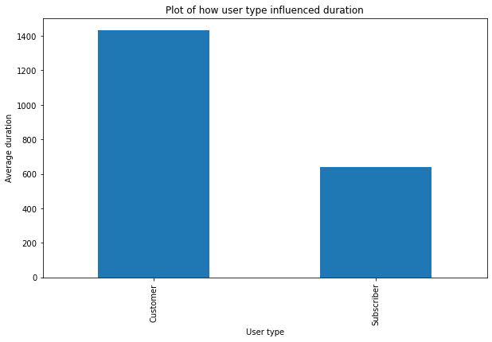

Insight: Maybe due to the imabalance between the count of customers and subscrubers, customers ride farther than subscribers on average.

## (Visualization 2)

> How member gender influenced average duration.

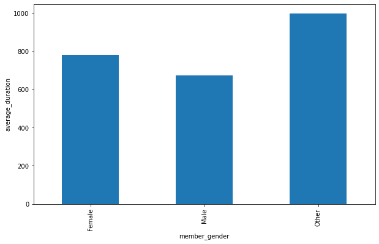

Insight: shockingly, those that identified as other has an average bike ride duration of 1000 sec followed by the females with about 750 sec while the male has ann average bike ride duration of about 700sec.

## (Visualization 3)

> How bike_share_for_all_trips influenced average duration.

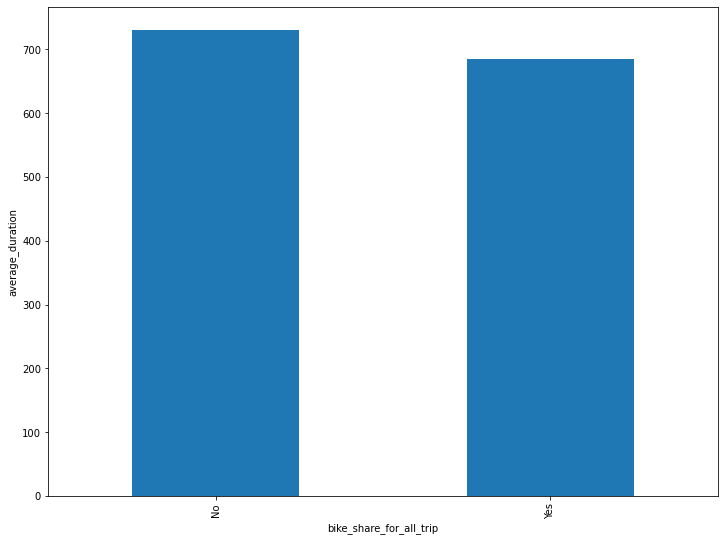

Users that didnt shared bike for all trip has a slightly higher duration in sec at average compared to those that shared.

# VIsualisation 4

> How member_gender(Male) , user_type relate with duration_sec on an average.

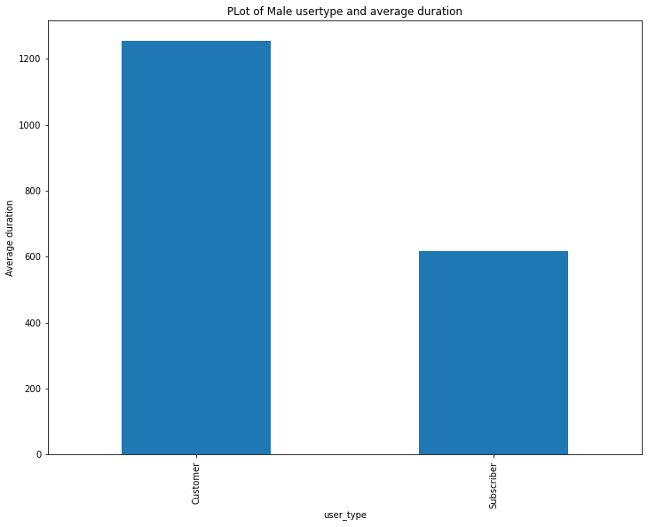

After investigating member_gender Male in relations to thier user type and thier average riding duration, we got to understand Men that are customers ride for a longer time period on an average when compared to subscribers.

# VIsualisation 5

> How member_gender(Female) , user_type relate with duration_sec on an average.

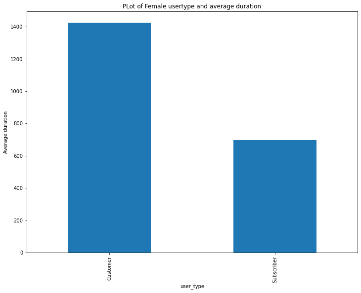

After investigating member_gender Female in relations to thier user type and thier average riding duration, we got to understand Females that are customers ride for a longer time period on an average when compared to subscribers